# **Análisis de la Distribución Geoespacial de las Especies de la Familia Centrolenidae en Costa Rica: Relación con Factores Ambientales**

**Introducción**

Las ranas de cristal, debido a su alta sensibilidad a los cambios ambientales, son consideradas bioindicadores fundamentales para evaluar la salud de los ecosistemas tropicales (Romero, 2023). Sin embargo, a pesar de su importancia ecológica, muchas especies de esta familia están en peligro debido a la deforestación, la contaminación de cuerpos de agua y otros factores antropogénicos (Torres, 2019). La falta de datos actualizados sobre su distribución y estado de conservación es un desafío para el desarrollo de estrategias de protección eficaces.

A través de este análisis, se pretende no solo generar conocimiento sobre la distribución actual de las especies de Centrolenidae en Costa Rica, sino también proporcionar una base científica para el diseño de políticas y programas de conservación que ayuden a mitigar los riesgos a los que estas especies están expuestas. Al entender cómo varía la presencia de estas ranas a lo largo del tiempo y el espacio, se podrán implementar estrategias de conservación más efectivas y focalizadas en las áreas más críticas para su preservación.

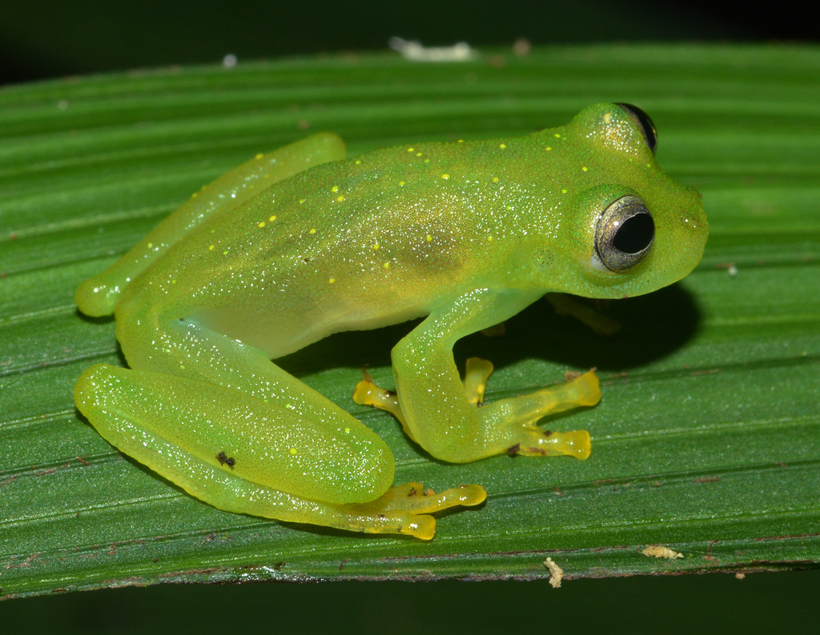

*Montar Google Drive*

```python
from google.colab import drive
drive.mount('/content/drive')
```

*Leer el archivo CSV desde Google Drive*

```python
!pip install gdown
```

```python
import gdown

# ID del archivo en Google Drive
file_id = '1pBsKrMhPTpQFQSOYLCroiHwAqwqNaEyW'

# URL para descargar el archivo
url = f'https://drive.google.com/uc?id={file_id}'

# Descargar el archivo CSV
output = 'Centrolenidae.csv'
gdown.download(url, output, quiet=False)
```

```
Downloading...
From: https://drive.google.com/uc?id=1pBsKrMhPTpQFQSOYLCroiHwAqwqNaEyW
To: /content/Centrolenidae.csv
```

```
'Centrolenidae.csv'
```

*Leer el archivo CSV en pandas*

```python
import pandas as pd

# Leer el archivo CSV descargado
df = pd.read_csv('Centrolenidae.csv')

# Información general del DataFrame
print(df.info())

# Ver las primeras filas para asegurar que los datos se cargaron correctamente
print(df.head())
```

```
<class 'pandas.core.frame.DataFrame'>
RangeIndex: 2566 entries, 0 to 2565
Data columns (total 29 columns):
 #   Column                         Non-Null Count  Dtype
---  ------                         --------------  -----
 0   id                             2566 non-null   int64
 1   observed_on_string             2566 non-null   object
 2   time_zone                      2566 non-null   object
 3   user_id                        2566 non-null   int64
 4   user_login                     2566 non-null   object
 5   created_at                     2566 non-null   object
 6   updated_at                     2566 non-null   object
 7   quality_grade                  2566 non-null   object
 8   url                            2566 non-null   object
 9   tag_list                       51 non-null     object
```

[output cut: 72 more lines]

*Revisar y seleccionar columnas relevantes*

```python
print(df.columns.tolist())
```

```
['id', 'observed_on_string', 'time_zone', 'user_id', 'user_login', 'created_at', 'updated_at', 'quality_grade', 'url', 'tag_list', 'description', 'num_identification_agreements', 'captive_cultivated', 'oauth_application_id', 'place_guess', 'latitude', 'longitude', 'positional_accuracy', 'private_pla…
```

*Visualización geoespacial*

```python
import folium
import pandas as pd

# Asegurar de que las coordenadas (latitud, longitud) sean válidas y no nulas
df_clean = df.dropna(subset=['latitude', 'longitude'])
df_clean = df_clean[(df_clean['latitude'] >= -90) & (df_clean['latitude'] <= 90)]
df_clean = df_clean[(df_clean['longitude'] >= -180) & (df_clean['longitude'] <= 180)]

# Crear el mapa centrado en Costa Rica
m = folium.Map(location=[9.19, -83.55], zoom_start=7)

# Agregar los puntos de observación al mapa
for index, row in df_clean.iterrows():
    folium.CircleMarker(
        location=[row['latitude'], row['longitude']],
        radius=5,
        color='blue',
        fill=True,
        fill_color='blue',
        fill_opacity=0.6
    ).add_to(m)

# Mostrar el mapa
m
```

Make this Notebook Trusted to load map: File -> Trust Notebook

[interactive chart not shown]

El mapa de observaciones geográficas muestra cómo se distribuyen las ranas de vidrio en Costa Rica. Al observar los puntos, se pueden identificar áreas con mayor concentración de observaciones, lo que sugiere que algunas regiones son más relevantes para estas especies, posiblemente por características de hábitat específicas como vegetación o cuerpos de agua. Sin embargo, si se encuentran puntos fuera de Costa Rica o dispersos en lugares improbables, esto podría indicar problemas en la precisión de los datos geográficos. Además, la ausencia de puntos en algunas zonas puede señalar vacíos en las observaciones, lo que podría estar relacionado con el acceso limitado o la falta de monitoreo en ciertas áreas.

Este análisis es importante para identificar zonas críticas que podrían necesitar más esfuerzos de conservación y para comprender mejor los patrones de distribución de la especie en el país.

```python
import pandas as pd

# Datos de ejemplo con coordenadas
data = {
    'latitud': [9.9383, 9.9271, 9.9523],
    'longitud': [-84.0833, -84.0420, -84.0755]
}

# Crear un DataFrame
ranita_df = pd.DataFrame(data)

# Guardar el DataFrame como un archivo CSV
ranita_df.to_csv('/content/ranita_ubicaciones.csv', index=False)

# Ver el archivo creado
print(ranita_df)
```

```
   latitud  longitud
0   9.9383  -84.0833
1   9.9271  -84.0420
2   9.9523  -84.0755
```

```python
import pandas as pd
import rasterio
from rasterio import sample

# Cargar las coordenadas de la ranita desde el archivo CSV
ranita_df = pd.read_csv('/content/ranita_ubicaciones.csv')

# Abrir el archivo raster de precipitaciones
with rasterio.open('/content/precip_cr.tif') as src:
    # Extraer valores de precipitaciones para las ubicaciones de la ranita
    latitudes = ranita_df['latitud'].values
    longitudes = ranita_df['longitud'].values

    # Crear una lista de las coordenadas (longitud, latitud)
    coords = [(lon, lat) for lon, lat in zip(longitudes, latitudes)]

    # Extraer valores de precipitaciones
    precip_values = [v[0] for v in src.sample(coords)]

# Agregar los valores de precipitaciones al DataFrame de las ubicaciones de la ranita
ranita_df['precipitacion'] = precip_values

# Mostrar los primeros registros
print(ranita_df.head())
```

```
   latitud  longitud  precipitacion
0   9.9383  -84.0833            329
1   9.9271  -84.0420            327
2   9.9523  -84.0755            339
```

```python
import folium
import pandas as pd
import rasterio
from rasterio import sample

# Cargar las coordenadas de la ranita desde el archivo CSV
ranita_df = pd.read_csv('/content/ranita_ubicaciones.csv')

# Abrir el archivo raster de precipitaciones
with rasterio.open('/content/precip_cr.tif') as src:
    # Extraer valores de precipitaciones para las ubicaciones de la ranita
    latitudes = ranita_df['latitud'].values
    longitudes = ranita_df['longitud'].values

    # Crear una lista de las coordenadas (longitud, latitud)
    coords = [(lon, lat) for lon, lat in zip(longitudes, latitudes)]

    # Extraer valores de precipitaciones
    precip_values = [v[0] for v in src.sample(coords)]

# Agregar los valores de precipitaciones al DataFrame de las ubicaciones de la ranita
ranita_df['precipitacion'] = precip_values

# Crear un mapa centrado en Costa Rica (aproximadamente)
mapa = folium.Map(location=[9.7489, -83.7534], zoom_start=7)

# Agregar las ubicaciones de las ranitas con sus valores de precipitación al mapa
for idx, row in ranita_df.iterrows():
    folium.Marker(
        location=[row['latitud'], row['longitud']],
        popup=f"Precipitación: {row['precipitacion']} mm",
        icon=folium.Icon(color="green", icon="cloud")
    ).add_to(mapa)

# Guardar el mapa en un archivo HTML
mapa.save('/content/mapa_ranitas.html')

# Mostrar el mapa en el notebook
mapa
```

Make this Notebook Trusted to load map: File -> Trust Notebook

[interactive chart not shown]

**Referencias Bibliográficas**

Costa Rican Amphibian Research Center. (s.f). Glass Frogs / Ranas de Vidrio. https://cramphibian.com/glass-frogs-ranas-de-vidrio/#:~:text=Ranas%20de%20Vidrio%20de%20Costa,de%20de%20Argentina%20y%20Bolivia.

Fisher, A. (2023). Cómo vive la rana de cristal, la especie única de anfibio que está perdiendo su hábitat en América Latina. National Geographic En Español. https://www.ngenespanol.com/animales/rana-de-cristal/

Forti, L. R., & Szabo, J. K. (2023). The iNaturalist platform as a source of data to study amphibians in Brazil. Anais da Academia Brasileira de Ciências, 95, e20220828.

Heberling, J. M., Miller, J. T., Noesgaard, D., Weingart, S. B., & Schigel, D. (2021). Data integration enables global biodiversity synthesis. Proceedings of the National Academy of Sciences, 118(6), e2018093118.

Rivera, M. (2022).Ranas de cristal. Rev. Acad. Colomb. Cienc. Ex. Fis. Nat. 46(179):585-586, abril-junio de 2022. doi: https://doi.org/10.18257/raccefyn.1714

Romero, R. (2023). ¿Qué tanto sabes de las ranas de cristal? | La trivia de Mongabay Latam. Noticias Ambientales. https://es.mongabay.com/2023/05/que-tanto-sabes-de-ranas-de-cristal-trivia/#:~:text=Las%20ranas%20de%20cristal%20son,un%20impacto%20en%20sus%20poblaciones.

Soberón, J., & Peterson, T. (2004). Biodiversity informatics: managing and applying primary biodiversity data. Philosophical Transactions of the Royal Society of London. Series B: Biological Sciences, 359(1444), 689-698.

Torres, N. (2019). Prpyecto de conservación de anfibios y uso sostenible de los recursos genéticos. Ministerio del Ambiente. https://www.amphibianark.org/wp-content/uploads/2021/11/Reproduccion-de-Atelopus-nanay.pdf

Zhang, J. (2017). Biodiversity science and macroecology in the era of big data. Biodiversity Science, 25(4), 355-363.